# 2023年度报告-净资产分析

使用em的业绩报告数据。

## 净资产

### 历年合计及增长

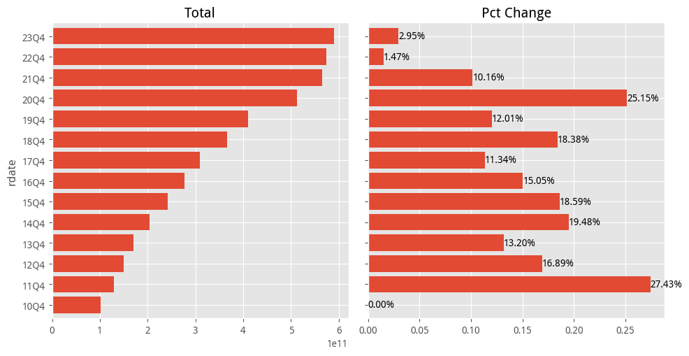

- 2023年净资产总和仍在增长，而且增长比22年还高，说明23年是在恢复之中。
- 2020年的净资产高增长可能是发新股和利润增长的共同结果。

|  | sum | mean | median | min | max |
| --- | --- | --- | --- | --- | --- |
| 0 | [工商银行](https://data.eastmoney.com/stockdata/601398.html) | [工商银行](https://data.eastmoney.com/stockdata/601398.html) | [工商银行](https://data.eastmoney.com/stockdata/601398.html) | [中国移动](https://data.eastmoney.com/stockdata/600941.html) | [工商银行](https://data.eastmoney.com/stockdata/601398.html) |
| 1 | [建设银行](https://data.eastmoney.com/stockdata/601939.html) | [建设银行](https://data.eastmoney.com/stockdata/601939.html) | [建设银行](https://data.eastmoney.com/stockdata/601939.html) | [中国石油](https://data.eastmoney.com/stockdata/601857.html) | [世纪华通](https://data.eastmoney.com/stockdata/002602.html) |
| 2 | [中国银行](https://data.eastmoney.com/stockdata/601988.html) | [中国银行](https://data.eastmoney.com/stockdata/601988.html) | [中国银行](https://data.eastmoney.com/stockdata/601988.html) | [工商银行](https://data.eastmoney.com/stockdata/601398.html) | [建设银行](https://data.eastmoney.com/stockdata/601939.html) |
| 3 | [农业银行](https://data.eastmoney.com/stockdata/601288.html) | [农业银行](https://data.eastmoney.com/stockdata/601288.html) | [农业银行](https://data.eastmoney.com/stockdata/601288.html) | [建设银行](https://data.eastmoney.com/stockdata/601939.html) | [农业银行](https://data.eastmoney.com/stockdata/601288.html) |
| 4 | [中国石油](https://data.eastmoney.com/stockdata/601857.html) | [中国石油](https://data.eastmoney.com/stockdata/601857.html) | [中国石油](https://data.eastmoney.com/stockdata/601857.html) | [中国银行](https://data.eastmoney.com/stockdata/601988.html) | [中国银行](https://data.eastmoney.com/stockdata/601988.html) |
| 5 | [中国石化](https://data.eastmoney.com/stockdata/600028.html) | [中国移动](https://data.eastmoney.com/stockdata/600941.html) | [中国移动](https://data.eastmoney.com/stockdata/600941.html) | [农业银行](https://data.eastmoney.com/stockdata/601288.html) | [中国石油](https://data.eastmoney.com/stockdata/601857.html) |
| 6 | [交通银行](https://data.eastmoney.com/stockdata/601328.html) | [中国石化](https://data.eastmoney.com/stockdata/600028.html) | [中国石化](https://data.eastmoney.com/stockdata/600028.html) | [中国石化](https://data.eastmoney.com/stockdata/600028.html) | [格林美](https://data.eastmoney.com/stockdata/002340.html) |
| 7 | [中国移动](https://data.eastmoney.com/stockdata/600941.html) | [交通银行](https://data.eastmoney.com/stockdata/601328.html) | [交通银行](https://data.eastmoney.com/stockdata/601328.html) | [中国海油](https://data.eastmoney.com/stockdata/600938.html) | [中国移动](https://data.eastmoney.com/stockdata/600941.html) |
| 8 | [中国平安](https://data.eastmoney.com/stockdata/601318.html) | [邮储银行](https://data.eastmoney.com/stockdata/601658.html) | [邮储银行](https://data.eastmoney.com/stockdata/601658.html) | [中国电信](https://data.eastmoney.com/stockdata/601728.html) | [电广传媒](https://data.eastmoney.com/stockdata/000917.html) |
| 9 | [招商银行](https://data.eastmoney.com/stockdata/600036.html) | [中国海油](https://data.eastmoney.com/stockdata/600938.html) | [中国海油](https://data.eastmoney.com/stockdata/600938.html) | [邮储银行](https://data.eastmoney.com/stockdata/601658.html) | [钒钛股份](https://data.eastmoney.com/stockdata/000629.html) |
| 10 | [世纪华通](https://data.eastmoney.com/stockdata/002602.html) | [中国平安](https://data.eastmoney.com/stockdata/601318.html) | [招商银行](https://data.eastmoney.com/stockdata/600036.html) | [中国人寿](https://data.eastmoney.com/stockdata/601628.html) | [交通银行](https://data.eastmoney.com/stockdata/601328.html) |
| 11 | [浦发银行](https://data.eastmoney.com/stockdata/600000.html) | [招商银行](https://data.eastmoney.com/stockdata/600036.html) | [中国平安](https://data.eastmoney.com/stockdata/601318.html) | [交通银行](https://data.eastmoney.com/stockdata/601328.html) | [招商银行](https://data.eastmoney.com/stockdata/600036.html) |
| 12 | [兴业银行](https://data.eastmoney.com/stockdata/601166.html) | [世纪华通](https://data.eastmoney.com/stockdata/002602.html) | [中国电信](https://data.eastmoney.com/stockdata/601728.html) | [中国神华](https://data.eastmoney.com/stockdata/601088.html) | [中国平安](https://data.eastmoney.com/stockdata/601318.html) |
| 13 | [中信银行](https://data.eastmoney.com/stockdata/601998.html) | [中国电信](https://data.eastmoney.com/stockdata/601728.html) | [浦发银行](https://data.eastmoney.com/stockdata/600000.html) | [京沪高铁](https://data.eastmoney.com/stockdata/601816.html) | [中国石化](https://data.eastmoney.com/stockdata/600028.html) |
| 14 | [民生银行](https://data.eastmoney.com/stockdata/600016.html) | [浦发银行](https://data.eastmoney.com/stockdata/600000.html) | [中信银行](https://data.eastmoney.com/stockdata/601998.html) | [招商银行](https://data.eastmoney.com/stockdata/600036.html) | [邮储银行](https://data.eastmoney.com/stockdata/601658.html) |
| 15 | [中国人寿](https://data.eastmoney.com/stockdata/601628.html) | [兴业银行](https://data.eastmoney.com/stockdata/601166.html) | [兴业银行](https://data.eastmoney.com/stockdata/601166.html) | [中信银行](https://data.eastmoney.com/stockdata/601998.html) | [兴业银行](https://data.eastmoney.com/stockdata/601166.html) |
| 16 | [中国神华](https://data.eastmoney.com/stockdata/601088.html) | [中信银行](https://data.eastmoney.com/stockdata/601998.html) | [民生银行](https://data.eastmoney.com/stockdata/600016.html) | [中国平安](https://data.eastmoney.com/stockdata/601318.html) | [大有能源](https://data.eastmoney.com/stockdata/600403.html) |
| 17 | [邮储银行](https://data.eastmoney.com/stockdata/601658.html) | [民生银行](https://data.eastmoney.com/stockdata/600016.html) | [中国人寿](https://data.eastmoney.com/stockdata/601628.html) | [宝钢股份](https://data.eastmoney.com/stockdata/600019.html) | [浦发银行](https://data.eastmoney.com/stockdata/600000.html) |
| 18 | [光大银行](https://data.eastmoney.com/stockdata/601818.html) | [中国人寿](https://data.eastmoney.com/stockdata/601628.html) | [中国神华](https://data.eastmoney.com/stockdata/601088.html) | [民生银行](https://data.eastmoney.com/stockdata/600016.html) | [神州高铁](https://data.eastmoney.com/stockdata/000008.html) |
| 19 | [中国建筑](https://data.eastmoney.com/stockdata/601668.html) | [中国神华](https://data.eastmoney.com/stockdata/601088.html) | [光大银行](https://data.eastmoney.com/stockdata/601818.html) | [浦发银行](https://data.eastmoney.com/stockdata/600000.html) | [中国海油](https://data.eastmoney.com/stockdata/600938.html) |

- 净资产最大值中，有一些奇怪的公司。比如格林美、钒钛股份、大有能源。感觉可能是数据错误。

### 总体变化

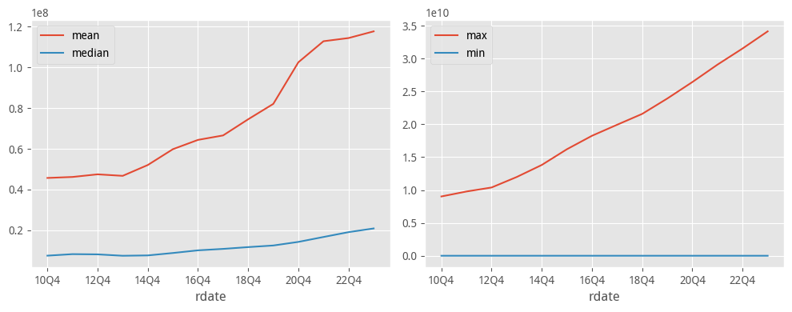

- 均值和中位数整体趋势仍在增长。中位数增长更低，说明强者增长更大。
- 净资产的平均值大于中位数，说明净资产集中在少数公司。

### 每年前20

| rdate | 10Q4 | 11Q4 | 12Q4 | 13Q4 | 14Q4 | 15Q4 | 16Q4 | 17Q4 | 18Q4 | 19Q4 | 20Q4 | 21Q4 | 22Q4 | 23Q4 |
| --- | --- | --- | --- | --- | --- | --- | --- | --- | --- | --- | --- | --- | --- | --- |
| 0 | [中国石油](https://data.eastmoney.com/stockdata/601857.html) | [中国石油](https://data.eastmoney.com/stockdata/601857.html) | [中国石油](https://data.eastmoney.com/stockdata/601857.html) | [工商银行](https://data.eastmoney.com/stockdata/601398.html) | [工商银行](https://data.eastmoney.com/stockdata/601398.html) | [工商银行](https://data.eastmoney.com/stockdata/601398.html) | [工商银行](https://data.eastmoney.com/stockdata/601398.html) | [工商银行](https://data.eastmoney.com/stockdata/601398.html) | [工商银行](https://data.eastmoney.com/stockdata/601398.html) | [工商银行](https://data.eastmoney.com/stockdata/601398.html) | [工商银行](https://data.eastmoney.com/stockdata/601398.html) | [世纪华通](https://data.eastmoney.com/stockdata/002602.html) | [工商银行](https://data.eastmoney.com/stockdata/601398.html) | [工商银行](https://data.eastmoney.com/stockdata/601398.html) |
| 1 | [工商银行](https://data.eastmoney.com/stockdata/601398.html) | [工商银行](https://data.eastmoney.com/stockdata/601398.html) | [工商银行](https://data.eastmoney.com/stockdata/601398.html) | [中国石油](https://data.eastmoney.com/stockdata/601857.html) | [建设银行](https://data.eastmoney.com/stockdata/601939.html) | [建设银行](https://data.eastmoney.com/stockdata/601939.html) | [建设银行](https://data.eastmoney.com/stockdata/601939.html) | [建设银行](https://data.eastmoney.com/stockdata/601939.html) | [建设银行](https://data.eastmoney.com/stockdata/601939.html) | [建设银行](https://data.eastmoney.com/stockdata/601939.html) | [建设银行](https://data.eastmoney.com/stockdata/601939.html) | [工商银行](https://data.eastmoney.com/stockdata/601398.html) | [世纪华通](https://data.eastmoney.com/stockdata/002602.html) | [建设银行](https://data.eastmoney.com/stockdata/601939.html) |
| 2 | [建设银行](https://data.eastmoney.com/stockdata/601939.html) | [建设银行](https://data.eastmoney.com/stockdata/601939.html) | [建设银行](https://data.eastmoney.com/stockdata/601939.html) | [建设银行](https://data.eastmoney.com/stockdata/601939.html) | [中国石油](https://data.eastmoney.com/stockdata/601857.html) | [中国石油](https://data.eastmoney.com/stockdata/601857.html) | [中国银行](https://data.eastmoney.com/stockdata/601988.html) | [中国银行](https://data.eastmoney.com/stockdata/601988.html) | [中国银行](https://data.eastmoney.com/stockdata/601988.html) | [农业银行](https://data.eastmoney.com/stockdata/601288.html) | [农业银行](https://data.eastmoney.com/stockdata/601288.html) | [建设银行](https://data.eastmoney.com/stockdata/601939.html) | [建设银行](https://data.eastmoney.com/stockdata/601939.html) | [农业银行](https://data.eastmoney.com/stockdata/601288.html) |
| 3 | [中国银行](https://data.eastmoney.com/stockdata/601988.html) | [中国银行](https://data.eastmoney.com/stockdata/601988.html) | [中国银行](https://data.eastmoney.com/stockdata/601988.html) | [中国银行](https://data.eastmoney.com/stockdata/601988.html) | [中国银行](https://data.eastmoney.com/stockdata/601988.html) | [中国银行](https://data.eastmoney.com/stockdata/601988.html) | [农业银行](https://data.eastmoney.com/stockdata/601288.html) | [农业银行](https://data.eastmoney.com/stockdata/601288.html) | [农业银行](https://data.eastmoney.com/stockdata/601288.html) | [中国银行](https://data.eastmoney.com/stockdata/601988.html) | [中国银行](https://data.eastmoney.com/stockdata/601988.html) | [农业银行](https://data.eastmoney.com/stockdata/601288.html) | [农业银行](https://data.eastmoney.com/stockdata/601288.html) | [中国银行](https://data.eastmoney.com/stockdata/601988.html) |
| 4 | [农业银行](https://data.eastmoney.com/stockdata/601288.html) | [农业银行](https://data.eastmoney.com/stockdata/601288.html) | [农业银行](https://data.eastmoney.com/stockdata/601288.html) | [农业银行](https://data.eastmoney.com/stockdata/601288.html) | [农业银行](https://data.eastmoney.com/stockdata/601288.html) | [农业银行](https://data.eastmoney.com/stockdata/601288.html) | [中国石油](https://data.eastmoney.com/stockdata/601857.html) | [中国石油](https://data.eastmoney.com/stockdata/601857.html) | [中国石油](https://data.eastmoney.com/stockdata/601857.html) | [中国石油](https://data.eastmoney.com/stockdata/601857.html) | [中国石油](https://data.eastmoney.com/stockdata/601857.html) | [中国银行](https://data.eastmoney.com/stockdata/601988.html) | [中国银行](https://data.eastmoney.com/stockdata/601988.html) | [中国石油](https://data.eastmoney.com/stockdata/601857.html) |
| 5 | [中国石化](https://data.eastmoney.com/stockdata/600028.html) | [中国石化](https://data.eastmoney.com/stockdata/600028.html) | [中国石化](https://data.eastmoney.com/stockdata/600028.html) | [中国石化](https://data.eastmoney.com/stockdata/600028.html) | [岳阳林纸](https://data.eastmoney.com/stockdata/600963.html) | [钒钛股份](https://data.eastmoney.com/stockdata/000629.html) | [中国石化](https://data.eastmoney.com/stockdata/600028.html) | [中国石化](https://data.eastmoney.com/stockdata/600028.html) | [中国移动](https://data.eastmoney.com/stockdata/600941.html) | [中国移动](https://data.eastmoney.com/stockdata/600941.html) | [中国移动](https://data.eastmoney.com/stockdata/600941.html) | [格林美](https://data.eastmoney.com/stockdata/002340.html) | [中国石油](https://data.eastmoney.com/stockdata/601857.html) | [中国移动](https://data.eastmoney.com/stockdata/600941.html) |
| 6 | [中国人寿](https://data.eastmoney.com/stockdata/601628.html) | [交通银行](https://data.eastmoney.com/stockdata/601328.html) | [交通银行](https://data.eastmoney.com/stockdata/601328.html) | [交通银行](https://data.eastmoney.com/stockdata/601328.html) | [中国石化](https://data.eastmoney.com/stockdata/600028.html) | [中国石化](https://data.eastmoney.com/stockdata/600028.html) | [钒钛股份](https://data.eastmoney.com/stockdata/000629.html) | [交通银行](https://data.eastmoney.com/stockdata/601328.html) | [中国石化](https://data.eastmoney.com/stockdata/600028.html) | [中国石化](https://data.eastmoney.com/stockdata/600028.html) | [电广传媒](https://data.eastmoney.com/stockdata/000917.html) | [中国石油](https://data.eastmoney.com/stockdata/601857.html) | [中国移动](https://data.eastmoney.com/stockdata/600941.html) | [交通银行](https://data.eastmoney.com/stockdata/601328.html) |
| 7 | [交通银行](https://data.eastmoney.com/stockdata/601328.html) | [中国神华](https://data.eastmoney.com/stockdata/601088.html) | [中国神华](https://data.eastmoney.com/stockdata/601088.html) | [中国神华](https://data.eastmoney.com/stockdata/601088.html) | [交通银行](https://data.eastmoney.com/stockdata/601328.html) | [交通银行](https://data.eastmoney.com/stockdata/601328.html) | [交通银行](https://data.eastmoney.com/stockdata/601328.html) | [中国平安](https://data.eastmoney.com/stockdata/601318.html) | [交通银行](https://data.eastmoney.com/stockdata/601328.html) | [交通银行](https://data.eastmoney.com/stockdata/601328.html) | [交通银行](https://data.eastmoney.com/stockdata/601328.html) | [中国移动](https://data.eastmoney.com/stockdata/600941.html) | [交通银行](https://data.eastmoney.com/stockdata/601328.html) | [招商银行](https://data.eastmoney.com/stockdata/600036.html) |
| 8 | [中国神华](https://data.eastmoney.com/stockdata/601088.html) | [中国人寿](https://data.eastmoney.com/stockdata/601628.html) | [中国人寿](https://data.eastmoney.com/stockdata/601628.html) | [招商银行](https://data.eastmoney.com/stockdata/600036.html) | [海南机场](https://data.eastmoney.com/stockdata/600515.html) | [招商银行](https://data.eastmoney.com/stockdata/600036.html) | [招商银行](https://data.eastmoney.com/stockdata/600036.html) | [招商银行](https://data.eastmoney.com/stockdata/600036.html) | [中国平安](https://data.eastmoney.com/stockdata/601318.html) | [中国平安](https://data.eastmoney.com/stockdata/601318.html) | [中国石化](https://data.eastmoney.com/stockdata/600028.html) | [交通银行](https://data.eastmoney.com/stockdata/601328.html) | [中国平安](https://data.eastmoney.com/stockdata/601318.html) | [中国平安](https://data.eastmoney.com/stockdata/601318.html) |
| 9 | [招商银行](https://data.eastmoney.com/stockdata/600036.html) | [招商银行](https://data.eastmoney.com/stockdata/600036.html) | [招商银行](https://data.eastmoney.com/stockdata/600036.html) | [中国人寿](https://data.eastmoney.com/stockdata/601628.html) | [招商银行](https://data.eastmoney.com/stockdata/600036.html) | [中国平安](https://data.eastmoney.com/stockdata/601318.html) | [中国平安](https://data.eastmoney.com/stockdata/601318.html) | [浦发银行](https://data.eastmoney.com/stockdata/600000.html) | [招商银行](https://data.eastmoney.com/stockdata/600036.html) | [招商银行](https://data.eastmoney.com/stockdata/600036.html) | [中国平安](https://data.eastmoney.com/stockdata/601318.html) | [中国平安](https://data.eastmoney.com/stockdata/601318.html) | [招商银行](https://data.eastmoney.com/stockdata/600036.html) | [中国石化](https://data.eastmoney.com/stockdata/600028.html) |
| 10 | [中信银行](https://data.eastmoney.com/stockdata/601998.html) | [中信银行](https://data.eastmoney.com/stockdata/601998.html) | [中信银行](https://data.eastmoney.com/stockdata/601998.html) | [中信银行](https://data.eastmoney.com/stockdata/601998.html) | [中国神华](https://data.eastmoney.com/stockdata/601088.html) | [中国人寿](https://data.eastmoney.com/stockdata/601628.html) | [中信银行](https://data.eastmoney.com/stockdata/601998.html) | [兴业银行](https://data.eastmoney.com/stockdata/601166.html) | [浦发银行](https://data.eastmoney.com/stockdata/600000.html) | [浦发银行](https://data.eastmoney.com/stockdata/600000.html) | [大有能源](https://data.eastmoney.com/stockdata/600403.html) | [中国石化](https://data.eastmoney.com/stockdata/600028.html) | [中国石化](https://data.eastmoney.com/stockdata/600028.html) | [邮储银行](https://data.eastmoney.com/stockdata/601658.html) |
| 11 | [中国平安](https://data.eastmoney.com/stockdata/601318.html) | [浦发银行](https://data.eastmoney.com/stockdata/600000.html) | [浦发银行](https://data.eastmoney.com/stockdata/600000.html) | [浦发银行](https://data.eastmoney.com/stockdata/600000.html) | [中国人寿](https://data.eastmoney.com/stockdata/601628.html) | [中国神华](https://data.eastmoney.com/stockdata/601088.html) | [浦发银行](https://data.eastmoney.com/stockdata/600000.html) | [邮储银行](https://data.eastmoney.com/stockdata/601658.html) | [邮储银行](https://data.eastmoney.com/stockdata/601658.html) | [兴业银行](https://data.eastmoney.com/stockdata/601166.html) | [神州高铁](https://data.eastmoney.com/stockdata/000008.html) | [招商银行](https://data.eastmoney.com/stockdata/600036.html) | [邮储银行](https://data.eastmoney.com/stockdata/601658.html) | [兴业银行](https://data.eastmoney.com/stockdata/601166.html) |
| 12 | [宝钢股份](https://data.eastmoney.com/stockdata/600019.html) | [中国平安](https://data.eastmoney.com/stockdata/601318.html) | [民生银行](https://data.eastmoney.com/stockdata/600016.html) | [兴业银行](https://data.eastmoney.com/stockdata/601166.html) | [中信银行](https://data.eastmoney.com/stockdata/601998.html) | [中信银行](https://data.eastmoney.com/stockdata/601998.html) | [民生银行](https://data.eastmoney.com/stockdata/600016.html) | [中信银行](https://data.eastmoney.com/stockdata/601998.html) | [兴业银行](https://data.eastmoney.com/stockdata/601166.html) | [邮储银行](https://data.eastmoney.com/stockdata/601658.html) | [招商银行](https://data.eastmoney.com/stockdata/600036.html) | [邮储银行](https://data.eastmoney.com/stockdata/601658.html) | [兴业银行](https://data.eastmoney.com/stockdata/601166.html) | [浦发银行](https://data.eastmoney.com/stockdata/600000.html) |
| 13 | [民生银行](https://data.eastmoney.com/stockdata/600016.html) | [民生银行](https://data.eastmoney.com/stockdata/600016.html) | [中国平安](https://data.eastmoney.com/stockdata/601318.html) | [民生银行](https://data.eastmoney.com/stockdata/600016.html) | [浦发银行](https://data.eastmoney.com/stockdata/600000.html) | [民生银行](https://data.eastmoney.com/stockdata/600016.html) | [兴业银行](https://data.eastmoney.com/stockdata/601166.html) | [民生银行](https://data.eastmoney.com/stockdata/600016.html) | [中国海油](https://data.eastmoney.com/stockdata/600938.html) | [中国海油](https://data.eastmoney.com/stockdata/600938.html) | [邮储银行](https://data.eastmoney.com/stockdata/601658.html) | [浦发银行](https://data.eastmoney.com/stockdata/600000.html) | [浦发银行](https://data.eastmoney.com/stockdata/600000.html) | [中国海油](https://data.eastmoney.com/stockdata/600938.html) |
| 14 | [浦发银行](https://data.eastmoney.com/stockdata/600000.html) | [ST红太阳](https://data.eastmoney.com/stockdata/000525.html) | [兴业银行](https://data.eastmoney.com/stockdata/601166.html) | [中国平安](https://data.eastmoney.com/stockdata/601318.html) | [兴业银行](https://data.eastmoney.com/stockdata/601166.html) | [浦发银行](https://data.eastmoney.com/stockdata/600000.html) | [中国人寿](https://data.eastmoney.com/stockdata/601628.html) | [中国人寿](https://data.eastmoney.com/stockdata/601628.html) | [中信银行](https://data.eastmoney.com/stockdata/601998.html) | [民生银行](https://data.eastmoney.com/stockdata/600016.html) | [浦发银行](https://data.eastmoney.com/stockdata/600000.html) | [兴业银行](https://data.eastmoney.com/stockdata/601166.html) | [中信银行](https://data.eastmoney.com/stockdata/601998.html) | [中信银行](https://data.eastmoney.com/stockdata/601998.html) |
| 15 | [中国太保](https://data.eastmoney.com/stockdata/601601.html) | [赛力斯](https://data.eastmoney.com/stockdata/601127.html) | [宝钢股份](https://data.eastmoney.com/stockdata/600019.html) | [上汽集团](https://data.eastmoney.com/stockdata/600104.html) | [民生银行](https://data.eastmoney.com/stockdata/600016.html) | [兴业银行](https://data.eastmoney.com/stockdata/601166.html) | [中国神华](https://data.eastmoney.com/stockdata/601088.html) | [中国神华](https://data.eastmoney.com/stockdata/601088.html) | [民生银行](https://data.eastmoney.com/stockdata/600016.html) | [中信银行](https://data.eastmoney.com/stockdata/601998.html) | [兴业银行](https://data.eastmoney.com/stockdata/601166.html) | [南都电源](https://data.eastmoney.com/stockdata/300068.html) | [民生银行](https://data.eastmoney.com/stockdata/600016.html) | [民生银行](https://data.eastmoney.com/stockdata/600016.html) |
| 16 | [中国建筑](https://data.eastmoney.com/stockdata/601668.html) | [兴业银行](https://data.eastmoney.com/stockdata/601166.html) | [上汽集团](https://data.eastmoney.com/stockdata/600104.html) | [光大银行](https://data.eastmoney.com/stockdata/601818.html) | [中国平安](https://data.eastmoney.com/stockdata/601318.html) | [唐山港](https://data.eastmoney.com/stockdata/601000.html) | [邮储银行](https://data.eastmoney.com/stockdata/601658.html) | [光大银行](https://data.eastmoney.com/stockdata/601818.html) | [中国电信](https://data.eastmoney.com/stockdata/601728.html) | [新乡化纤](https://data.eastmoney.com/stockdata/000949.html) | [民生银行](https://data.eastmoney.com/stockdata/600016.html) | [民生银行](https://data.eastmoney.com/stockdata/600016.html) | [中国海油](https://data.eastmoney.com/stockdata/600938.html) | [光大银行](https://data.eastmoney.com/stockdata/601818.html) |
| 17 | [兴业银行](https://data.eastmoney.com/stockdata/601166.html) | [宝钢股份](https://data.eastmoney.com/stockdata/600019.html) | [光大银行](https://data.eastmoney.com/stockdata/601818.html) | [宝钢股份](https://data.eastmoney.com/stockdata/600019.html) | [光大银行](https://data.eastmoney.com/stockdata/601818.html) | [光大银行](https://data.eastmoney.com/stockdata/601818.html) | [光大银行](https://data.eastmoney.com/stockdata/601818.html) | [中国建筑](https://data.eastmoney.com/stockdata/601668.html) | [中国人寿](https://data.eastmoney.com/stockdata/601628.html) | [中国人寿](https://data.eastmoney.com/stockdata/601628.html) | [中信银行](https://data.eastmoney.com/stockdata/601998.html) | [中信银行](https://data.eastmoney.com/stockdata/601998.html) | [中国人寿](https://data.eastmoney.com/stockdata/601628.html) | [中国人寿](https://data.eastmoney.com/stockdata/601628.html) |
| 18 | [泰山石油](https://data.eastmoney.com/stockdata/000554.html) | [上汽集团](https://data.eastmoney.com/stockdata/600104.html) | [中国建筑](https://data.eastmoney.com/stockdata/601668.html) | [中国建筑](https://data.eastmoney.com/stockdata/601668.html) | [上汽集团](https://data.eastmoney.com/stockdata/600104.html) | [上汽集团](https://data.eastmoney.com/stockdata/600104.html) | [中国建筑](https://data.eastmoney.com/stockdata/601668.html) | [上汽集团](https://data.eastmoney.com/stockdata/600104.html) | [中国神华](https://data.eastmoney.com/stockdata/601088.html) | [中国电信](https://data.eastmoney.com/stockdata/601728.html) | [海能达](https://data.eastmoney.com/stockdata/002583.html) | [中国人寿](https://data.eastmoney.com/stockdata/601628.html) | [光大银行](https://data.eastmoney.com/stockdata/601818.html) | [中国电信](https://data.eastmoney.com/stockdata/601728.html) |
| 19 | [中国联通](https://data.eastmoney.com/stockdata/600050.html) | [光大银行](https://data.eastmoney.com/stockdata/601818.html) | [首钢股份](https://data.eastmoney.com/stockdata/000959.html) | [中国太保](https://data.eastmoney.com/stockdata/601601.html) | [中国建筑](https://data.eastmoney.com/stockdata/601668.html) | [中国建筑](https://data.eastmoney.com/stockdata/601668.html) | [上汽集团](https://data.eastmoney.com/stockdata/600104.html) | [平安银行](https://data.eastmoney.com/stockdata/000001.html) | [光大银行](https://data.eastmoney.com/stockdata/601818.html) | [中国神华](https://data.eastmoney.com/stockdata/601088.html) | [中国海油](https://data.eastmoney.com/stockdata/600938.html) | [ST长康](https://data.eastmoney.com/stockdata/002435.html) | [中国电信](https://data.eastmoney.com/stockdata/601728.html) | [平安银行](https://data.eastmoney.com/stockdata/000001.html) |

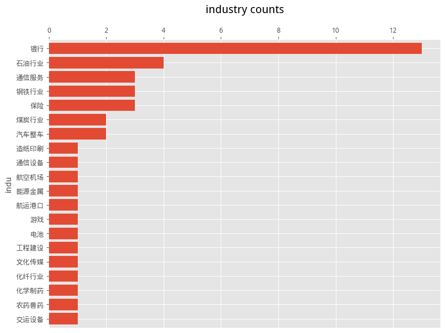

[figure not shown]

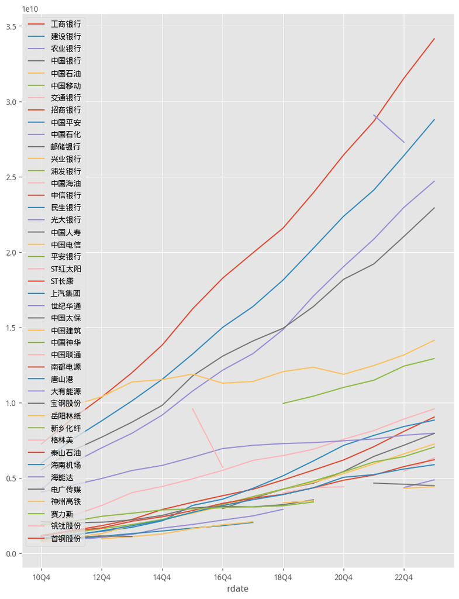

- 平安和招商两大金融巨头咬得很紧。

### 最近一年分布

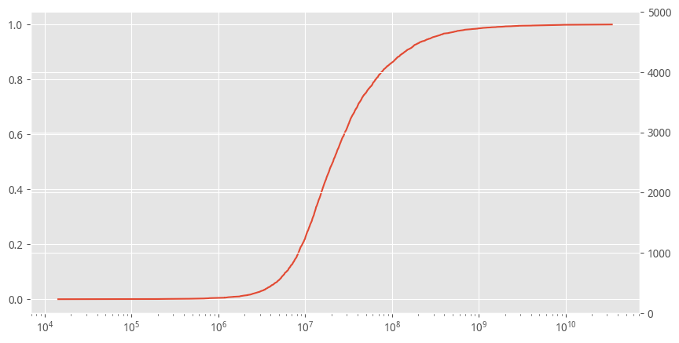

- 大约85%的公司在净资产在亿级以下。

## TOP300

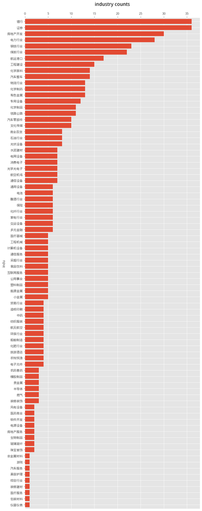

- 净资产高的行业集中在银行、房地产开发、电力、钢铁等。

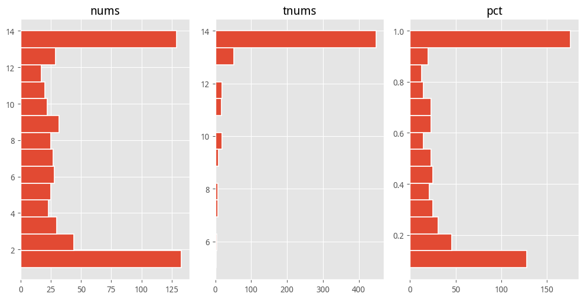

- 老钱的净资产更多。

1

[中国太保](https://data.eastmoney.com/stockdata/601601.html)

2

[中信证券](https://data.eastmoney.com/stockdata/600030.html)

3

[中国交建](https://data.eastmoney.com/stockdata/601800.html)

4

[中国铁建](https://data.eastmoney.com/stockdata/601186.html)

5

[北京银行](https://data.eastmoney.com/stockdata/601169.html)

6

[上汽集团](https://data.eastmoney.com/stockdata/600104.html)

7

[中国建筑](https://data.eastmoney.com/stockdata/601668.html)

8

[中国中铁](https://data.eastmoney.com/stockdata/601390.html)

9

[华夏银行](https://data.eastmoney.com/stockdata/600015.html)

10

[中国神华](https://data.eastmoney.com/stockdata/601088.html)

11

[中国人寿](https://data.eastmoney.com/stockdata/601628.html)

12

[平安银行](https://data.eastmoney.com/stockdata/000001.html)

13

[光大银行](https://data.eastmoney.com/stockdata/601818.html)

14

[荣盛发展](https://data.eastmoney.com/stockdata/002146.html)

15

[贵州茅台](https://data.eastmoney.com/stockdata/600519.html)

16

[海通证券](https://data.eastmoney.com/stockdata/600837.html)

17

[中国联通](https://data.eastmoney.com/stockdata/600050.html)

18

[中国中车](https://data.eastmoney.com/stockdata/601766.html)

19

[宁波银行](https://data.eastmoney.com/stockdata/002142.html)

20

[中远海控](https://data.eastmoney.com/stockdata/601919.html)

21

[保利发展](https://data.eastmoney.com/stockdata/600048.html)

22

[海螺水泥](https://data.eastmoney.com/stockdata/600585.html)

23

[长江电力](https://data.eastmoney.com/stockdata/600900.html)

24

[广汽集团](https://data.eastmoney.com/stockdata/601238.html)

25

[上海石化](https://data.eastmoney.com/stockdata/600688.html)

26

[招商证券](https://data.eastmoney.com/stockdata/600999.html)

27

[中国东航](https://data.eastmoney.com/stockdata/600115.html)

28

[西南证券](https://data.eastmoney.com/stockdata/600369.html)

29

[新兴铸管](https://data.eastmoney.com/stockdata/000778.html)

30

[海油工程](https://data.eastmoney.com/stockdata/600583.html)

31

[中国银行](https://data.eastmoney.com/stockdata/601988.html)

32

[招商银行](https://data.eastmoney.com/stockdata/600036.html)

33

[民生银行](https://data.eastmoney.com/stockdata/600016.html)

34

[中信银行](https://data.eastmoney.com/stockdata/601998.html)

35

[兴业银行](https://data.eastmoney.com/stockdata/601166.html)

36

[浦发银行](https://data.eastmoney.com/stockdata/600000.html)

37

[中海油服](https://data.eastmoney.com/stockdata/601808.html)

38

[上港集团](https://data.eastmoney.com/stockdata/600018.html)

39

[大秦铁路](https://data.eastmoney.com/stockdata/601006.html)

40

[中国中冶](https://data.eastmoney.com/stockdata/601618.html)

41

[比亚迪](https://data.eastmoney.com/stockdata/002594.html)

42

[广发证券](https://data.eastmoney.com/stockdata/000776.html)

43

[中煤能源](https://data.eastmoney.com/stockdata/601898.html)

44

[中国电建](https://data.eastmoney.com/stockdata/601669.html)

45

[南京银行](https://data.eastmoney.com/stockdata/601009.html)

46

[兖矿能源](https://data.eastmoney.com/stockdata/600188.html)

47

[吉林敖东](https://data.eastmoney.com/stockdata/000623.html)

48

[华泰证券](https://data.eastmoney.com/stockdata/601688.html)

49

[海尔智家](https://data.eastmoney.com/stockdata/600690.html)

50

[紫金矿业](https://data.eastmoney.com/stockdata/601899.html)

51

[广深铁路](https://data.eastmoney.com/stockdata/601333.html)

52

[新华保险](https://data.eastmoney.com/stockdata/601336.html)

53

[格力电器](https://data.eastmoney.com/stockdata/000651.html)

54

[陕西煤业](https://data.eastmoney.com/stockdata/601225.html)

55

[华能国际](https://data.eastmoney.com/stockdata/600011.html)

56

[宁波港](https://data.eastmoney.com/stockdata/601018.html)

57

[海康威视](https://data.eastmoney.com/stockdata/002415.html)

58

[江西铜业](https://data.eastmoney.com/stockdata/600362.html)

59

[辽宁成大](https://data.eastmoney.com/stockdata/600739.html)

60

[渤海租赁](https://data.eastmoney.com/stockdata/000415.html)

61

[隧道股份](https://data.eastmoney.com/stockdata/600820.html)

62

[马钢股份](https://data.eastmoney.com/stockdata/600808.html)

63

[河钢股份](https://data.eastmoney.com/stockdata/000709.html)

64

[金隅集团](https://data.eastmoney.com/stockdata/601992.html)

65

[三一重工](https://data.eastmoney.com/stockdata/600031.html)

66

[浙江龙盛](https://data.eastmoney.com/stockdata/600352.html)

67

[宁沪高速](https://data.eastmoney.com/stockdata/600377.html)

68

[青岛银行](https://data.eastmoney.com/stockdata/002948.html)

69

[中兴通讯](https://data.eastmoney.com/stockdata/000063.html)

70

[光大证券](https://data.eastmoney.com/stockdata/601788.html)

71

[潍柴动力](https://data.eastmoney.com/stockdata/000338.html)

72

[万华化学](https://data.eastmoney.com/stockdata/600309.html)

73

[中国重工](https://data.eastmoney.com/stockdata/601989.html)

74

[中远海发](https://data.eastmoney.com/stockdata/601866.html)

75

[福耀玻璃](https://data.eastmoney.com/stockdata/600660.html)

76

[长江证券](https://data.eastmoney.com/stockdata/000783.html)

77

[申能股份](https://data.eastmoney.com/stockdata/600642.html)

78

[湖北能源](https://data.eastmoney.com/stockdata/000883.html)

79

[长城汽车](https://data.eastmoney.com/stockdata/601633.html)

80

[上海医药](https://data.eastmoney.com/stockdata/601607.html)

81

[金地集团](https://data.eastmoney.com/stockdata/600383.html)

82

[特变电工](https://data.eastmoney.com/stockdata/600089.html)

83

[中国铝业](https://data.eastmoney.com/stockdata/601600.html)

84

[华域汽车](https://data.eastmoney.com/stockdata/600741.html)

85

[中国化学](https://data.eastmoney.com/stockdata/601117.html)

86

[鞍钢股份](https://data.eastmoney.com/stockdata/000898.html)

87

[洛阳钼业](https://data.eastmoney.com/stockdata/603993.html)

88

[中联重科](https://data.eastmoney.com/stockdata/000157.html)

89

[山东高速](https://data.eastmoney.com/stockdata/600350.html)

90

[川投能源](https://data.eastmoney.com/stockdata/600674.html)

91

[太钢不锈](https://data.eastmoney.com/stockdata/000825.html)

92

[国元证券](https://data.eastmoney.com/stockdata/000728.html)

93

[中远海能](https://data.eastmoney.com/stockdata/600026.html)

94

[长安汽车](https://data.eastmoney.com/stockdata/000625.html)

95

[建设银行](https://data.eastmoney.com/stockdata/601939.html)

96

[农业银行](https://data.eastmoney.com/stockdata/601288.html)

97

[交通银行](https://data.eastmoney.com/stockdata/601328.html)

98

[中国石油](https://data.eastmoney.com/stockdata/601857.html)

99

[工商银行](https://data.eastmoney.com/stockdata/601398.html)

100

[中国平安](https://data.eastmoney.com/stockdata/601318.html)

101

[中国石化](https://data.eastmoney.com/stockdata/600028.html)

102

[新湖中宝](https://data.eastmoney.com/stockdata/600208.html)

103

[复星医药](https://data.eastmoney.com/stockdata/600196.html)

104

[中集集团](https://data.eastmoney.com/stockdata/000039.html)

105

[方正证券](https://data.eastmoney.com/stockdata/601901.html)

106

[上海建工](https://data.eastmoney.com/stockdata/600170.html)

107

[南山铝业](https://data.eastmoney.com/stockdata/600219.html)

108

[泸州老窖](https://data.eastmoney.com/stockdata/000568.html)

109

[招商轮船](https://data.eastmoney.com/stockdata/601872.html)

110

[东方电气](https://data.eastmoney.com/stockdata/600875.html)

111

[包钢股份](https://data.eastmoney.com/stockdata/600010.html)

112

[国投电力](https://data.eastmoney.com/stockdata/600886.html)

113

[伊利股份](https://data.eastmoney.com/stockdata/600887.html)

114

[中国国航](https://data.eastmoney.com/stockdata/601111.html)

115

[金风科技](https://data.eastmoney.com/stockdata/002202.html)

116

[雅戈尔](https://data.eastmoney.com/stockdata/600177.html)

117

[洋河股份](https://data.eastmoney.com/stockdata/002304.html)

118

[首钢股份](https://data.eastmoney.com/stockdata/000959.html)

119

[建发股份](https://data.eastmoney.com/stockdata/600153.html)

120

[TCL科技](https://data.eastmoney.com/stockdata/000100.html)

121

[辽港股份](https://data.eastmoney.com/stockdata/601880.html)

122

[上海机场](https://data.eastmoney.com/stockdata/600009.html)

123

[云南白药](https://data.eastmoney.com/stockdata/000538.html)

124

[南方航空](https://data.eastmoney.com/stockdata/600029.html)

125

[徐工机械](https://data.eastmoney.com/stockdata/000425.html)

126

[上海电气](https://data.eastmoney.com/stockdata/601727.html)

127

[潞安环能](https://data.eastmoney.com/stockdata/601699.html)

128

[深圳能源](https://data.eastmoney.com/stockdata/000027.html)

129

[国电电力](https://data.eastmoney.com/stockdata/600795.html)

130

[江苏银行](https://data.eastmoney.com/stockdata/600919.html)

131

[上海银行](https://data.eastmoney.com/stockdata/601229.html)

132

[宝钢股份](https://data.eastmoney.com/stockdata/600019.html)

133

[美的集团](https://data.eastmoney.com/stockdata/000333.html)

134

[杭州银行](https://data.eastmoney.com/stockdata/600926.html)

135

[国信证券](https://data.eastmoney.com/stockdata/002736.html)

136

[国泰君安](https://data.eastmoney.com/stockdata/601211.html)

137

[成都银行](https://data.eastmoney.com/stockdata/601838.html)

138

[浙能电力](https://data.eastmoney.com/stockdata/600023.html)

139

[中国核电](https://data.eastmoney.com/stockdata/601985.html)

140

[东方证券](https://data.eastmoney.com/stockdata/600958.html)

141

[中国银河](https://data.eastmoney.com/stockdata/601881.html)

142

[贵阳银行](https://data.eastmoney.com/stockdata/601997.html)

143

[华电国际](https://data.eastmoney.com/stockdata/600027.html)

144

[苏州银行](https://data.eastmoney.com/stockdata/002966.html)

145

[申万宏源](https://data.eastmoney.com/stockdata/000166.html)

146

[西安银行](https://data.eastmoney.com/stockdata/600928.html)

147

[华能水电](https://data.eastmoney.com/stockdata/600025.html)

148

[郑州银行](https://data.eastmoney.com/stockdata/002936.html)

149

[招商蛇口](https://data.eastmoney.com/stockdata/001979.html)

150

[长沙银行](https://data.eastmoney.com/stockdata/601577.html)

151

[青农商行](https://data.eastmoney.com/stockdata/002958.html)

152

[温氏股份](https://data.eastmoney.com/stockdata/300498.html)

153

[青岛港](https://data.eastmoney.com/stockdata/601298.html)

154

[渝农商行](https://data.eastmoney.com/stockdata/601077.html)

155

[浙商银行](https://data.eastmoney.com/stockdata/601916.html)

156

[中国人保](https://data.eastmoney.com/stockdata/601319.html)

157

[中信建投](https://data.eastmoney.com/stockdata/601066.html)

158

[中国广核](https://data.eastmoney.com/stockdata/003816.html)

159

[中国外运](https://data.eastmoney.com/stockdata/601598.html)

160

[招商公路](https://data.eastmoney.com/stockdata/001965.html)

161

[工业富联](https://data.eastmoney.com/stockdata/601138.html)

162

[重庆银行](https://data.eastmoney.com/stockdata/601963.html)

```
大金融：43 | 占比：0.26543209876543206
```

1

[中国太保](https://data.eastmoney.com/stockdata/601601.html)

2

[中国交建](https://data.eastmoney.com/stockdata/601800.html)

3

[中国铁建](https://data.eastmoney.com/stockdata/601186.html)

4

[上汽集团](https://data.eastmoney.com/stockdata/600104.html)

5

[中国建筑](https://data.eastmoney.com/stockdata/601668.html)

6

[中国中铁](https://data.eastmoney.com/stockdata/601390.html)

7

[中国神华](https://data.eastmoney.com/stockdata/601088.html)

8

[中国人寿](https://data.eastmoney.com/stockdata/601628.html)

9

[荣盛发展](https://data.eastmoney.com/stockdata/002146.html)

10

[贵州茅台](https://data.eastmoney.com/stockdata/600519.html)

11

[中国联通](https://data.eastmoney.com/stockdata/600050.html)

12

[中国中车](https://data.eastmoney.com/stockdata/601766.html)

13

[中远海控](https://data.eastmoney.com/stockdata/601919.html)

14

[保利发展](https://data.eastmoney.com/stockdata/600048.html)

15

[海螺水泥](https://data.eastmoney.com/stockdata/600585.html)

16

[长江电力](https://data.eastmoney.com/stockdata/600900.html)

17

[广汽集团](https://data.eastmoney.com/stockdata/601238.html)

18

[上海石化](https://data.eastmoney.com/stockdata/600688.html)

19

[中国东航](https://data.eastmoney.com/stockdata/600115.html)

20

[新兴铸管](https://data.eastmoney.com/stockdata/000778.html)

21

[海油工程](https://data.eastmoney.com/stockdata/600583.html)

22

[中海油服](https://data.eastmoney.com/stockdata/601808.html)

23

[上港集团](https://data.eastmoney.com/stockdata/600018.html)

24

[大秦铁路](https://data.eastmoney.com/stockdata/601006.html)

25

[中国中冶](https://data.eastmoney.com/stockdata/601618.html)

26

[比亚迪](https://data.eastmoney.com/stockdata/002594.html)

27

[中煤能源](https://data.eastmoney.com/stockdata/601898.html)

28

[中国电建](https://data.eastmoney.com/stockdata/601669.html)

29

[兖矿能源](https://data.eastmoney.com/stockdata/600188.html)

30

[吉林敖东](https://data.eastmoney.com/stockdata/000623.html)

31

[海尔智家](https://data.eastmoney.com/stockdata/600690.html)

32

[紫金矿业](https://data.eastmoney.com/stockdata/601899.html)

33

[广深铁路](https://data.eastmoney.com/stockdata/601333.html)

34

[格力电器](https://data.eastmoney.com/stockdata/000651.html)

35

[陕西煤业](https://data.eastmoney.com/stockdata/601225.html)

36

[华能国际](https://data.eastmoney.com/stockdata/600011.html)

37

[宁波港](https://data.eastmoney.com/stockdata/601018.html)

38

[海康威视](https://data.eastmoney.com/stockdata/002415.html)

39

[江西铜业](https://data.eastmoney.com/stockdata/600362.html)

40

[辽宁成大](https://data.eastmoney.com/stockdata/600739.html)

41

[渤海租赁](https://data.eastmoney.com/stockdata/000415.html)

42

[隧道股份](https://data.eastmoney.com/stockdata/600820.html)

43

[马钢股份](https://data.eastmoney.com/stockdata/600808.html)

44

[河钢股份](https://data.eastmoney.com/stockdata/000709.html)

45

[金隅集团](https://data.eastmoney.com/stockdata/601992.html)

46

[三一重工](https://data.eastmoney.com/stockdata/600031.html)

47

[浙江龙盛](https://data.eastmoney.com/stockdata/600352.html)

48

[宁沪高速](https://data.eastmoney.com/stockdata/600377.html)

49

[中兴通讯](https://data.eastmoney.com/stockdata/000063.html)

50

[潍柴动力](https://data.eastmoney.com/stockdata/000338.html)

51

[万华化学](https://data.eastmoney.com/stockdata/600309.html)

52

[中国重工](https://data.eastmoney.com/stockdata/601989.html)

53

[中远海发](https://data.eastmoney.com/stockdata/601866.html)

54

[福耀玻璃](https://data.eastmoney.com/stockdata/600660.html)

55

[申能股份](https://data.eastmoney.com/stockdata/600642.html)

56

[湖北能源](https://data.eastmoney.com/stockdata/000883.html)

57

[长城汽车](https://data.eastmoney.com/stockdata/601633.html)

58

[上海医药](https://data.eastmoney.com/stockdata/601607.html)

59

[金地集团](https://data.eastmoney.com/stockdata/600383.html)

60

[特变电工](https://data.eastmoney.com/stockdata/600089.html)

61

[中国铝业](https://data.eastmoney.com/stockdata/601600.html)

62

[华域汽车](https://data.eastmoney.com/stockdata/600741.html)

63

[中国化学](https://data.eastmoney.com/stockdata/601117.html)

64

[鞍钢股份](https://data.eastmoney.com/stockdata/000898.html)

65

[洛阳钼业](https://data.eastmoney.com/stockdata/603993.html)

66

[中联重科](https://data.eastmoney.com/stockdata/000157.html)

67

[山东高速](https://data.eastmoney.com/stockdata/600350.html)

68

[川投能源](https://data.eastmoney.com/stockdata/600674.html)

69

[太钢不锈](https://data.eastmoney.com/stockdata/000825.html)

70

[中远海能](https://data.eastmoney.com/stockdata/600026.html)

71

[长安汽车](https://data.eastmoney.com/stockdata/000625.html)

72

[中国石油](https://data.eastmoney.com/stockdata/601857.html)

73

[中国平安](https://data.eastmoney.com/stockdata/601318.html)

74

[中国石化](https://data.eastmoney.com/stockdata/600028.html)

75

[新湖中宝](https://data.eastmoney.com/stockdata/600208.html)

76

[复星医药](https://data.eastmoney.com/stockdata/600196.html)

77

[中集集团](https://data.eastmoney.com/stockdata/000039.html)

78

[上海建工](https://data.eastmoney.com/stockdata/600170.html)

79

[南山铝业](https://data.eastmoney.com/stockdata/600219.html)

80

[泸州老窖](https://data.eastmoney.com/stockdata/000568.html)

81

[招商轮船](https://data.eastmoney.com/stockdata/601872.html)

82

[东方电气](https://data.eastmoney.com/stockdata/600875.html)

83

[包钢股份](https://data.eastmoney.com/stockdata/600010.html)

84

[国投电力](https://data.eastmoney.com/stockdata/600886.html)

85

[伊利股份](https://data.eastmoney.com/stockdata/600887.html)

86

[中国国航](https://data.eastmoney.com/stockdata/601111.html)

87

[金风科技](https://data.eastmoney.com/stockdata/002202.html)

88

[雅戈尔](https://data.eastmoney.com/stockdata/600177.html)

89

[洋河股份](https://data.eastmoney.com/stockdata/002304.html)

90

[首钢股份](https://data.eastmoney.com/stockdata/000959.html)

91

[建发股份](https://data.eastmoney.com/stockdata/600153.html)

92

[TCL科技](https://data.eastmoney.com/stockdata/000100.html)

93

[辽港股份](https://data.eastmoney.com/stockdata/601880.html)

94

[上海机场](https://data.eastmoney.com/stockdata/600009.html)

95

[云南白药](https://data.eastmoney.com/stockdata/000538.html)

96

[南方航空](https://data.eastmoney.com/stockdata/600029.html)

97

[徐工机械](https://data.eastmoney.com/stockdata/000425.html)

98

[上海电气](https://data.eastmoney.com/stockdata/601727.html)

99

[潞安环能](https://data.eastmoney.com/stockdata/601699.html)

100

[深圳能源](https://data.eastmoney.com/stockdata/000027.html)

101

[国电电力](https://data.eastmoney.com/stockdata/600795.html)

102

[宝钢股份](https://data.eastmoney.com/stockdata/600019.html)

103

[美的集团](https://data.eastmoney.com/stockdata/000333.html)

104

[国泰君安](https://data.eastmoney.com/stockdata/601211.html)

105

[浙能电力](https://data.eastmoney.com/stockdata/600023.html)

106

[中国核电](https://data.eastmoney.com/stockdata/601985.html)

107

[中国银河](https://data.eastmoney.com/stockdata/601881.html)

108

[华电国际](https://data.eastmoney.com/stockdata/600027.html)

109

[申万宏源](https://data.eastmoney.com/stockdata/000166.html)

110

[华能水电](https://data.eastmoney.com/stockdata/600025.html)

111

[招商蛇口](https://data.eastmoney.com/stockdata/001979.html)

112

[温氏股份](https://data.eastmoney.com/stockdata/300498.html)

113

[青岛港](https://data.eastmoney.com/stockdata/601298.html)

114

[中国人保](https://data.eastmoney.com/stockdata/601319.html)

115

[中信建投](https://data.eastmoney.com/stockdata/601066.html)

116

[中国广核](https://data.eastmoney.com/stockdata/003816.html)

117

[中国外运](https://data.eastmoney.com/stockdata/601598.html)

118

[招商公路](https://data.eastmoney.com/stockdata/001965.html)

119

[工业富联](https://data.eastmoney.com/stockdata/601138.html)

## 增长情况

- 选择了有6期以上报告的公司，测试其近5年利润增长的夏普指数平均值，从高到低排列。

### 总体情况

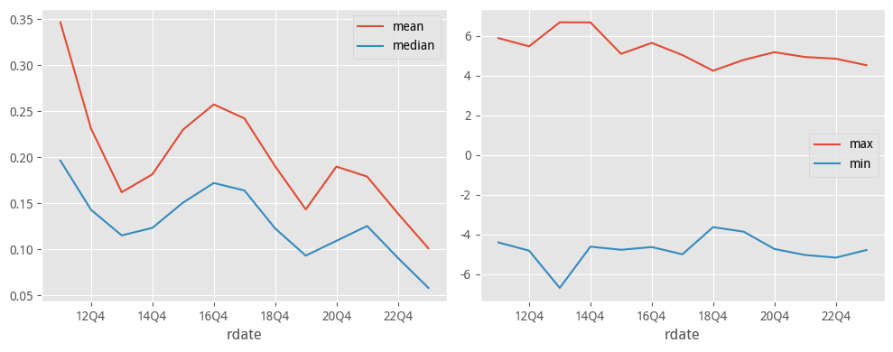

- 增长下滑。均值和中位数都创历史新低。
- 极值缩小。

### 增长排名

|  | cname | nums | tnums | pct |
| --- | --- | --- | --- | --- |
| 0 | 明德生物 | 6 | 11 | 0.545455 |
| 1 | 小熊电器 | 5 | 8 | 0.625000 |
| 2 | 喜悦智行 | 5 | 9 | 0.555556 |
| 3 | 固德威 | 5 | 10 | 0.500000 |
| 4 | 中科微至 | 5 | 6 | 0.833333 |
| 5 | 毕得医药 | 5 | 5 | 1.000000 |
| 6 | 利和兴 | 5 | 10 | 0.500000 |
| 7 | 飞沃科技 | 5 | 9 | 0.555556 |
| 8 | 显盈科技 | 5 | 9 | 0.555556 |
| 9 | 海南机场 | 5 | 13 | 0.384615 |
| 10 | 复洁环保 | 5 | 8 | 0.625000 |
| 11 | 光库科技 | 5 | 11 | 0.454545 |
| 12 | 广立微 | 5 | 5 | 1.000000 |
| 13 | 观想科技 | 5 | 10 | 0.500000 |
| 14 | 卓胜微 | 5 | 9 | 0.555556 |
| 15 | 天下秀 | 5 | 9 | 0.555556 |
| 16 | 义翘神州 | 5 | 6 | 0.833333 |
| 17 | 润阳科技 | 4 | 10 | 0.400000 |
| 18 | ST联络 | 4 | 13 | 0.307692 |
| 19 | *ST美尚 | 4 | 12 | 0.333333 |

- 净资产增长速度较快的，看来没有很多熟悉的公司。

### 最近一年增长情况

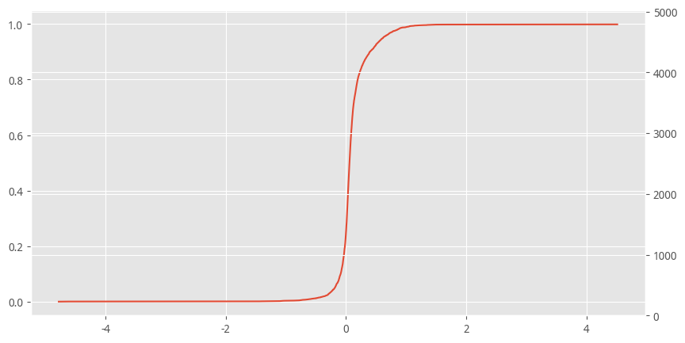

- 大部分公司净资产增长有限。

### 夏普指数

- 夏普指数衡量增长的质量，比单纯看增长率要好一点。
- 以下是近五年夏普指数平均后的前300排名。

1

[百合股份](https://data.eastmoney.com/stockdata/603102.html)

2

[恒瑞医药](https://data.eastmoney.com/stockdata/600276.html)

3

[屹通新材](https://data.eastmoney.com/stockdata/300930.html)

4

[保利发展](https://data.eastmoney.com/stockdata/600048.html)

5

[马应龙](https://data.eastmoney.com/stockdata/600993.html)

6

[华润三九](https://data.eastmoney.com/stockdata/000999.html)

7

[起帆电缆](https://data.eastmoney.com/stockdata/605222.html)

8

[贵航股份](https://data.eastmoney.com/stockdata/600523.html)

9

[宏润建设](https://data.eastmoney.com/stockdata/002062.html)

10

[卓易信息](https://data.eastmoney.com/stockdata/688258.html)

11

[志特新材](https://data.eastmoney.com/stockdata/300986.html)

12

[渝农商行](https://data.eastmoney.com/stockdata/601077.html)

13

[神马电力](https://data.eastmoney.com/stockdata/603530.html)

14

[龙净环保](https://data.eastmoney.com/stockdata/600388.html)

15

[百洋医药](https://data.eastmoney.com/stockdata/301015.html)

16

[力鼎光电](https://data.eastmoney.com/stockdata/605118.html)

17

[航民股份](https://data.eastmoney.com/stockdata/600987.html)

18

[南山智尚](https://data.eastmoney.com/stockdata/300918.html)

19

[甘李药业](https://data.eastmoney.com/stockdata/603087.html)

20

[浙江大农](https://data.eastmoney.com/stockdata/831855.html)

21

[皖通高速](https://data.eastmoney.com/stockdata/600012.html)

22

[德才股份](https://data.eastmoney.com/stockdata/605287.html)

23

[天地在线](https://data.eastmoney.com/stockdata/002995.html)

24

[法狮龙](https://data.eastmoney.com/stockdata/605318.html)

25

[广联航空](https://data.eastmoney.com/stockdata/300900.html)

26

[森麒麟](https://data.eastmoney.com/stockdata/002984.html)

27

[青鸟消防](https://data.eastmoney.com/stockdata/002960.html)

28

[晶雪节能](https://data.eastmoney.com/stockdata/301010.html)

29

[海昌新材](https://data.eastmoney.com/stockdata/300885.html)

30

[青岛食品](https://data.eastmoney.com/stockdata/001219.html)

31

[杭州银行](https://data.eastmoney.com/stockdata/600926.html)

32

[贵州茅台](https://data.eastmoney.com/stockdata/600519.html)

33

[中国铁建](https://data.eastmoney.com/stockdata/601186.html)

34

[长鸿高科](https://data.eastmoney.com/stockdata/605008.html)

35

[贝特瑞](https://data.eastmoney.com/stockdata/835185.html)

36

[成都银行](https://data.eastmoney.com/stockdata/601838.html)

37

[蓝盾光电](https://data.eastmoney.com/stockdata/300862.html)

38

[恒生电子](https://data.eastmoney.com/stockdata/600570.html)

39

[法拉电子](https://data.eastmoney.com/stockdata/600563.html)

40

[德赛电池](https://data.eastmoney.com/stockdata/000049.html)

41

[联发股份](https://data.eastmoney.com/stockdata/002394.html)

42

[高测股份](https://data.eastmoney.com/stockdata/688556.html)

43

[广大特材](https://data.eastmoney.com/stockdata/688186.html)

44

[贵阳银行](https://data.eastmoney.com/stockdata/601997.html)

45

[江阴银行](https://data.eastmoney.com/stockdata/002807.html)

46

[东莞控股](https://data.eastmoney.com/stockdata/000828.html)

47

[英诺激光](https://data.eastmoney.com/stockdata/301021.html)

48

[伊力特](https://data.eastmoney.com/stockdata/600197.html)

49

[华翔股份](https://data.eastmoney.com/stockdata/603112.html)

50

[赛伍技术](https://data.eastmoney.com/stockdata/603212.html)

51

[长沙银行](https://data.eastmoney.com/stockdata/601577.html)

52

[中兰环保](https://data.eastmoney.com/stockdata/300854.html)

53

[航天电器](https://data.eastmoney.com/stockdata/002025.html)

54

[铁大科技](https://data.eastmoney.com/stockdata/872541.html)

55

[利通科技](https://data.eastmoney.com/stockdata/832225.html)

56

[小商品城](https://data.eastmoney.com/stockdata/600415.html)

57

[浙江龙盛](https://data.eastmoney.com/stockdata/600352.html)

58

[五洲特纸](https://data.eastmoney.com/stockdata/605007.html)

59

[帅丰电器](https://data.eastmoney.com/stockdata/605336.html)

60

[长华集团](https://data.eastmoney.com/stockdata/605018.html)

61

[宇新股份](https://data.eastmoney.com/stockdata/002986.html)

62

[福建高速](https://data.eastmoney.com/stockdata/600033.html)

63

[北元集团](https://data.eastmoney.com/stockdata/601568.html)

64

[华特达因](https://data.eastmoney.com/stockdata/000915.html)

65

[金龙鱼](https://data.eastmoney.com/stockdata/300999.html)

66

[大唐药业](https://data.eastmoney.com/stockdata/836433.html)

67

[天地源](https://data.eastmoney.com/stockdata/600665.html)

68

[凌玮科技](https://data.eastmoney.com/stockdata/301373.html)

69

[工商银行](https://data.eastmoney.com/stockdata/601398.html)

70

[富奥股份](https://data.eastmoney.com/stockdata/000030.html)

71

[邮储银行](https://data.eastmoney.com/stockdata/601658.html)

72

[凯赛生物](https://data.eastmoney.com/stockdata/688065.html)

73

[新产业](https://data.eastmoney.com/stockdata/300832.html)

74

[华亚智能](https://data.eastmoney.com/stockdata/003043.html)

75

[甬金股份](https://data.eastmoney.com/stockdata/603995.html)

76

[苏州银行](https://data.eastmoney.com/stockdata/002966.html)

77

[豪悦护理](https://data.eastmoney.com/stockdata/605009.html)

78

[沪农商行](https://data.eastmoney.com/stockdata/601825.html)

79

[联德股份](https://data.eastmoney.com/stockdata/605060.html)

80

[招商银行](https://data.eastmoney.com/stockdata/600036.html)

81

[维海德](https://data.eastmoney.com/stockdata/301318.html)

82

[中国建筑](https://data.eastmoney.com/stockdata/601668.html)

83

[创识科技](https://data.eastmoney.com/stockdata/300941.html)

84

[建设银行](https://data.eastmoney.com/stockdata/601939.html)

85

[华森制药](https://data.eastmoney.com/stockdata/002907.html)

86

[赣粤高速](https://data.eastmoney.com/stockdata/600269.html)

87

[通策医疗](https://data.eastmoney.com/stockdata/600763.html)

88

[中岩大地](https://data.eastmoney.com/stockdata/003001.html)

89

[铁科轨道](https://data.eastmoney.com/stockdata/688569.html)

90

[狄耐克](https://data.eastmoney.com/stockdata/300884.html)

91

[日久光电](https://data.eastmoney.com/stockdata/003015.html)

92

[中国中铁](https://data.eastmoney.com/stockdata/601390.html)

93

[波长光电](https://data.eastmoney.com/stockdata/301421.html)

94

[苏农银行](https://data.eastmoney.com/stockdata/603323.html)

95

[海螺水泥](https://data.eastmoney.com/stockdata/600585.html)

96

[太阳纸业](https://data.eastmoney.com/stockdata/002078.html)

97

[佳合科技](https://data.eastmoney.com/stockdata/872392.html)

98

[同济科技](https://data.eastmoney.com/stockdata/600846.html)

99

[卓创资讯](https://data.eastmoney.com/stockdata/301299.html)

100

[德邦股份](https://data.eastmoney.com/stockdata/603056.html)

101

[海康威视](https://data.eastmoney.com/stockdata/002415.html)

102

[晨光新材](https://data.eastmoney.com/stockdata/605399.html)

103

[中谷物流](https://data.eastmoney.com/stockdata/603565.html)

104

[万泰生物](https://data.eastmoney.com/stockdata/603392.html)

105

[杭州热电](https://data.eastmoney.com/stockdata/605011.html)

106

[金橙子](https://data.eastmoney.com/stockdata/688291.html)

107

[华兰生物](https://data.eastmoney.com/stockdata/002007.html)

108

[苏轴股份](https://data.eastmoney.com/stockdata/430418.html)

109

[沪江材料](https://data.eastmoney.com/stockdata/870204.html)

110

[盛航股份](https://data.eastmoney.com/stockdata/001205.html)

111

[常熟银行](https://data.eastmoney.com/stockdata/601128.html)

112

[厦门银行](https://data.eastmoney.com/stockdata/601187.html)

113

[科前生物](https://data.eastmoney.com/stockdata/688526.html)

114

[宇信科技](https://data.eastmoney.com/stockdata/300674.html)

115

[骏成科技](https://data.eastmoney.com/stockdata/301106.html)

116

[江苏银行](https://data.eastmoney.com/stockdata/600919.html)

117

[超达装备](https://data.eastmoney.com/stockdata/301186.html)

118

[天正电气](https://data.eastmoney.com/stockdata/605066.html)

119

[视源股份](https://data.eastmoney.com/stockdata/002841.html)

120

[测绘股份](https://data.eastmoney.com/stockdata/300826.html)

121

[太湖雪](https://data.eastmoney.com/stockdata/838262.html)

122

[南大环境](https://data.eastmoney.com/stockdata/300864.html)

123

[中国国贸](https://data.eastmoney.com/stockdata/600007.html)

124

[味知香](https://data.eastmoney.com/stockdata/605089.html)

125

[玉禾田](https://data.eastmoney.com/stockdata/300815.html)

126

[彩虹集团](https://data.eastmoney.com/stockdata/003023.html)

127

[爱克股份](https://data.eastmoney.com/stockdata/300889.html)

128

[宏裕包材](https://data.eastmoney.com/stockdata/837174.html)

129

[派克新材](https://data.eastmoney.com/stockdata/605123.html)

130

[山东赫达](https://data.eastmoney.com/stockdata/002810.html)

131

[盛视科技](https://data.eastmoney.com/stockdata/002990.html)

132

[民生银行](https://data.eastmoney.com/stockdata/600016.html)

133

[则成电子](https://data.eastmoney.com/stockdata/837821.html)

134

[金富科技](https://data.eastmoney.com/stockdata/003018.html)

135

[恩华药业](https://data.eastmoney.com/stockdata/002262.html)

136

[秋田微](https://data.eastmoney.com/stockdata/300939.html)

137

[信濠光电](https://data.eastmoney.com/stockdata/301051.html)

138

[盛德鑫泰](https://data.eastmoney.com/stockdata/300881.html)

139

[开勒股份](https://data.eastmoney.com/stockdata/301070.html)

140

[巴比食品](https://data.eastmoney.com/stockdata/605338.html)

141

[东星医疗](https://data.eastmoney.com/stockdata/301290.html)

142

[国子软件](https://data.eastmoney.com/stockdata/872953.html)

143

[尖峰集团](https://data.eastmoney.com/stockdata/600668.html)

144

[兆威机电](https://data.eastmoney.com/stockdata/003021.html)

145

[航天信息](https://data.eastmoney.com/stockdata/600271.html)

146

[一鸣食品](https://data.eastmoney.com/stockdata/605179.html)

147

[开普检测](https://data.eastmoney.com/stockdata/003008.html)

148

[野马电池](https://data.eastmoney.com/stockdata/605378.html)

149

[交建股份](https://data.eastmoney.com/stockdata/603815.html)

150

[新洁能](https://data.eastmoney.com/stockdata/605111.html)

151

[八方股份](https://data.eastmoney.com/stockdata/603489.html)

152

[万德斯](https://data.eastmoney.com/stockdata/688178.html)

153

[仙鹤股份](https://data.eastmoney.com/stockdata/603733.html)

154

[张家港行](https://data.eastmoney.com/stockdata/002839.html)

155

[三角防务](https://data.eastmoney.com/stockdata/300775.html)

156

[康辰药业](https://data.eastmoney.com/stockdata/603590.html)

157

[嘉美包装](https://data.eastmoney.com/stockdata/002969.html)

158

[华业香料](https://data.eastmoney.com/stockdata/300886.html)

159

[隆华新材](https://data.eastmoney.com/stockdata/301149.html)

160

[扬农化工](https://data.eastmoney.com/stockdata/600486.html)

161

[武商集团](https://data.eastmoney.com/stockdata/000501.html)

162

[康弘药业](https://data.eastmoney.com/stockdata/002773.html)

163

[智新电子](https://data.eastmoney.com/stockdata/837212.html)

164

[中熔电气](https://data.eastmoney.com/stockdata/301031.html)

165

[中国银行](https://data.eastmoney.com/stockdata/601988.html)

166

[新城控股](https://data.eastmoney.com/stockdata/601155.html)

167

[瑜欣电子](https://data.eastmoney.com/stockdata/301107.html)

168

[回盛生物](https://data.eastmoney.com/stockdata/300871.html)

169

[宇瞳光学](https://data.eastmoney.com/stockdata/300790.html)

170

[石头科技](https://data.eastmoney.com/stockdata/688169.html)

171

[昊帆生物](https://data.eastmoney.com/stockdata/301393.html)

172

[青农商行](https://data.eastmoney.com/stockdata/002958.html)

173

[建发股份](https://data.eastmoney.com/stockdata/600153.html)

174

[威胜信息](https://data.eastmoney.com/stockdata/688100.html)

175

[麒盛科技](https://data.eastmoney.com/stockdata/603610.html)

176

[密尔克卫](https://data.eastmoney.com/stockdata/603713.html)

177

[吉林高速](https://data.eastmoney.com/stockdata/601518.html)

178

[龙利得](https://data.eastmoney.com/stockdata/300883.html)

179

[华达新材](https://data.eastmoney.com/stockdata/605158.html)

180

[健民集团](https://data.eastmoney.com/stockdata/600976.html)

181

[伟明环保](https://data.eastmoney.com/stockdata/603568.html)

182

[金陵药业](https://data.eastmoney.com/stockdata/000919.html)

183

[宁波银行](https://data.eastmoney.com/stockdata/002142.html)

184

[三和管桩](https://data.eastmoney.com/stockdata/003037.html)

185

[优机股份](https://data.eastmoney.com/stockdata/833943.html)

186

[大华股份](https://data.eastmoney.com/stockdata/002236.html)

187

[万胜智能](https://data.eastmoney.com/stockdata/300882.html)

188

[菲菱科思](https://data.eastmoney.com/stockdata/301191.html)

189

[大地海洋](https://data.eastmoney.com/stockdata/301068.html)

190

[万孚生物](https://data.eastmoney.com/stockdata/300482.html)

191

[锐明技术](https://data.eastmoney.com/stockdata/002970.html)

192

[东方通信](https://data.eastmoney.com/stockdata/600776.html)

193

[广道数字](https://data.eastmoney.com/stockdata/839680.html)

194

[永冠新材](https://data.eastmoney.com/stockdata/603681.html)

195

[中简科技](https://data.eastmoney.com/stockdata/300777.html)

196

[口子窖](https://data.eastmoney.com/stockdata/603589.html)

197

[中国平安](https://data.eastmoney.com/stockdata/601318.html)

198

[聚赛龙](https://data.eastmoney.com/stockdata/301131.html)

199

[派瑞股份](https://data.eastmoney.com/stockdata/300831.html)

200

[中炬高新](https://data.eastmoney.com/stockdata/600872.html)

201

[创业环保](https://data.eastmoney.com/stockdata/600874.html)

202

[小熊电器](https://data.eastmoney.com/stockdata/002959.html)

203

[崇达技术](https://data.eastmoney.com/stockdata/002815.html)

204

[奇正藏药](https://data.eastmoney.com/stockdata/002287.html)

205

[鲁阳节能](https://data.eastmoney.com/stockdata/002088.html)

206

[上海银行](https://data.eastmoney.com/stockdata/601229.html)

207

[无锡银行](https://data.eastmoney.com/stockdata/600908.html)

208

[健帆生物](https://data.eastmoney.com/stockdata/300529.html)

209

[久量股份](https://data.eastmoney.com/stockdata/300808.html)

210

[伯特利](https://data.eastmoney.com/stockdata/603596.html)

211

[中国卫通](https://data.eastmoney.com/stockdata/601698.html)

212

[上海沿浦](https://data.eastmoney.com/stockdata/605128.html)

213

[中国交建](https://data.eastmoney.com/stockdata/601800.html)

214

[金丹科技](https://data.eastmoney.com/stockdata/300829.html)

215

[嘉曼服饰](https://data.eastmoney.com/stockdata/301276.html)

216

[景津装备](https://data.eastmoney.com/stockdata/603279.html)

217

[工大科雅](https://data.eastmoney.com/stockdata/301197.html)

218

[曲江文旅](https://data.eastmoney.com/stockdata/600706.html)

219

[兴业银行](https://data.eastmoney.com/stockdata/601166.html)

220

[热景生物](https://data.eastmoney.com/stockdata/688068.html)

221

[威腾电气](https://data.eastmoney.com/stockdata/688226.html)

222

[亿田智能](https://data.eastmoney.com/stockdata/300911.html)

223

[一汽富维](https://data.eastmoney.com/stockdata/600742.html)

224

[天箭科技](https://data.eastmoney.com/stockdata/002977.html)

225

[祥源新材](https://data.eastmoney.com/stockdata/300980.html)

226

[捷安高科](https://data.eastmoney.com/stockdata/300845.html)

227

[美硕科技](https://data.eastmoney.com/stockdata/301295.html)

228

[节能国祯](https://data.eastmoney.com/stockdata/300388.html)

229

[永东股份](https://data.eastmoney.com/stockdata/002753.html)

230

[时空科技](https://data.eastmoney.com/stockdata/605178.html)

231

[旭升集团](https://data.eastmoney.com/stockdata/603305.html)

232

[新中港](https://data.eastmoney.com/stockdata/605162.html)

233

[晟楠科技](https://data.eastmoney.com/stockdata/837006.html)

234

[禾丰股份](https://data.eastmoney.com/stockdata/603609.html)

235

[翔楼新材](https://data.eastmoney.com/stockdata/301160.html)

236

[锦盛新材](https://data.eastmoney.com/stockdata/300849.html)

237

[瑞丰新材](https://data.eastmoney.com/stockdata/300910.html)

238

[中信银行](https://data.eastmoney.com/stockdata/601998.html)

239

[健之佳](https://data.eastmoney.com/stockdata/605266.html)

240

[立航科技](https://data.eastmoney.com/stockdata/603261.html)

241

[明星电力](https://data.eastmoney.com/stockdata/600101.html)

242

[中国人保](https://data.eastmoney.com/stockdata/601319.html)

243

[大族激光](https://data.eastmoney.com/stockdata/002008.html)

244

[鸿远电子](https://data.eastmoney.com/stockdata/603267.html)

245

[冰轮环境](https://data.eastmoney.com/stockdata/000811.html)

246

[浩洋股份](https://data.eastmoney.com/stockdata/300833.html)

247

[唐源电气](https://data.eastmoney.com/stockdata/300789.html)

248

[明新旭腾](https://data.eastmoney.com/stockdata/605068.html)

249

[中科软](https://data.eastmoney.com/stockdata/603927.html)

250

[香飘飘](https://data.eastmoney.com/stockdata/603711.html)

251

[绝味食品](https://data.eastmoney.com/stockdata/603517.html)

252

[世纪恒通](https://data.eastmoney.com/stockdata/301428.html)

253

[汇绿生态](https://data.eastmoney.com/stockdata/001267.html)

254

[中信出版](https://data.eastmoney.com/stockdata/300788.html)

255

[云创数据](https://data.eastmoney.com/stockdata/835305.html)

256

[安徽合力](https://data.eastmoney.com/stockdata/600761.html)

257

[因赛集团](https://data.eastmoney.com/stockdata/300781.html)

258

[豪美新材](https://data.eastmoney.com/stockdata/002988.html)

259

[苏文电能](https://data.eastmoney.com/stockdata/300982.html)

260

[数字人](https://data.eastmoney.com/stockdata/835670.html)

261

[奥海科技](https://data.eastmoney.com/stockdata/002993.html)

262

[汉维科技](https://data.eastmoney.com/stockdata/836957.html)

263

[深水海纳](https://data.eastmoney.com/stockdata/300961.html)

264

[李子园](https://data.eastmoney.com/stockdata/605337.html)

265

[汉鑫科技](https://data.eastmoney.com/stockdata/837092.html)

266

[建业股份](https://data.eastmoney.com/stockdata/603948.html)

267

[三友联众](https://data.eastmoney.com/stockdata/300932.html)

268

[欧晶科技](https://data.eastmoney.com/stockdata/001269.html)

269

[蓝晓科技](https://data.eastmoney.com/stockdata/300487.html)

270

[安图生物](https://data.eastmoney.com/stockdata/603658.html)

271

[一诺威](https://data.eastmoney.com/stockdata/834261.html)

272

[立讯精密](https://data.eastmoney.com/stockdata/002475.html)

273

[银河微电](https://data.eastmoney.com/stockdata/688689.html)

274

[科锐国际](https://data.eastmoney.com/stockdata/300662.html)

275

[芒果超媒](https://data.eastmoney.com/stockdata/300413.html)

276

[江天化学](https://data.eastmoney.com/stockdata/300927.html)

277

[海晨股份](https://data.eastmoney.com/stockdata/300873.html)

278

[中天火箭](https://data.eastmoney.com/stockdata/003009.html)

279

[协创数据](https://data.eastmoney.com/stockdata/300857.html)

280

[泉峰汽车](https://data.eastmoney.com/stockdata/603982.html)

281

[隆利科技](https://data.eastmoney.com/stockdata/300752.html)

282

[仁和药业](https://data.eastmoney.com/stockdata/000650.html)

283

[大参林](https://data.eastmoney.com/stockdata/603233.html)

284

[新亚电子](https://data.eastmoney.com/stockdata/605277.html)

285

[维康药业](https://data.eastmoney.com/stockdata/300878.html)

286

[中国出版](https://data.eastmoney.com/stockdata/601949.html)

287

[德源药业](https://data.eastmoney.com/stockdata/832735.html)

288

[海大集团](https://data.eastmoney.com/stockdata/002311.html)

289

[玲珑轮胎](https://data.eastmoney.com/stockdata/601966.html)

290

[滨江集团](https://data.eastmoney.com/stockdata/002244.html)

291

[光力科技](https://data.eastmoney.com/stockdata/300480.html)

292

[嘉戎技术](https://data.eastmoney.com/stockdata/301148.html)

293

[创益通](https://data.eastmoney.com/stockdata/300991.html)

294

[花溪科技](https://data.eastmoney.com/stockdata/872895.html)

295

[祥鑫科技](https://data.eastmoney.com/stockdata/002965.html)

296

[燕麦科技](https://data.eastmoney.com/stockdata/688312.html)

297

[安井食品](https://data.eastmoney.com/stockdata/603345.html)

298

[西安银行](https://data.eastmoney.com/stockdata/600928.html)

299

[中国中免](https://data.eastmoney.com/stockdata/601888.html)

300

[思进智能](https://data.eastmoney.com/stockdata/003025.html)

## 金额和增长

13

[恒瑞医药](https://data.eastmoney.com/stockdata/600276.html)

8.02

13

[保利发展](https://data.eastmoney.com/stockdata/600048.html)

6.89

13

[华润三九](https://data.eastmoney.com/stockdata/000999.html)

5.70

9

[渝农商行](https://data.eastmoney.com/stockdata/601077.html)

5.11

13

[皖通高速](https://data.eastmoney.com/stockdata/600012.html)

4.49

12

[杭州银行](https://data.eastmoney.com/stockdata/600926.html)

4.09

13

[贵州茅台](https://data.eastmoney.com/stockdata/600519.html)

4.06

13

[中国铁建](https://data.eastmoney.com/stockdata/601186.html)

3.95

12

[成都银行](https://data.eastmoney.com/stockdata/601838.html)

3.84

12

[贵阳银行](https://data.eastmoney.com/stockdata/601997.html)

3.54

10

[长沙银行](https://data.eastmoney.com/stockdata/601577.html)

3.48

13

[小商品城](https://data.eastmoney.com/stockdata/600415.html)

3.40

13

[浙江龙盛](https://data.eastmoney.com/stockdata/600352.html)

3.39

13

[福建高速](https://data.eastmoney.com/stockdata/600033.html)

3.32

7

[金龙鱼](https://data.eastmoney.com/stockdata/300999.html)

3.30

10

[富奥股份](https://data.eastmoney.com/stockdata/000030.html)

3.24

13

[工商银行](https://data.eastmoney.com/stockdata/601398.html)

3.24

7

[邮储银行](https://data.eastmoney.com/stockdata/601658.html)

3.23

11

[苏州银行](https://data.eastmoney.com/stockdata/002966.html)

3.22

7

[沪农商行](https://data.eastmoney.com/stockdata/601825.html)

3.17

13

[招商银行](https://data.eastmoney.com/stockdata/600036.html)

3.12

13

[中国建筑](https://data.eastmoney.com/stockdata/601668.html)

3.09

13

[建设银行](https://data.eastmoney.com/stockdata/601939.html)

3.08

13

[赣粤高速](https://data.eastmoney.com/stockdata/600269.html)

3.03

13

[中国中铁](https://data.eastmoney.com/stockdata/601390.html)

2.99

13

[海螺水泥](https://data.eastmoney.com/stockdata/600585.html)

2.93

13

[太阳纸业](https://data.eastmoney.com/stockdata/002078.html)

2.93

13

[海康威视](https://data.eastmoney.com/stockdata/002415.html)

2.89

12

[常熟银行](https://data.eastmoney.com/stockdata/601128.html)

2.78

9

[厦门银行](https://data.eastmoney.com/stockdata/601187.html)

2.77

12

[江苏银行](https://data.eastmoney.com/stockdata/600919.html)

2.76

13

[中国国贸](https://data.eastmoney.com/stockdata/600007.html)

2.70

13

[民生银行](https://data.eastmoney.com/stockdata/600016.html)

2.66

13

[航天信息](https://data.eastmoney.com/stockdata/600271.html)

2.61

13

[中国银行](https://data.eastmoney.com/stockdata/601988.html)

2.54

10

[新城控股](https://data.eastmoney.com/stockdata/601155.html)

2.54

13

[建发股份](https://data.eastmoney.com/stockdata/600153.html)

2.53

10

[青农商行](https://data.eastmoney.com/stockdata/002958.html)

2.53

13

[大华股份](https://data.eastmoney.com/stockdata/002236.html)

2.46

13

[宁波银行](https://data.eastmoney.com/stockdata/002142.html)

2.46

13

[中国平安](https://data.eastmoney.com/stockdata/601318.html)

2.41

13

[创业环保](https://data.eastmoney.com/stockdata/600874.html)

2.38

12

[上海银行](https://data.eastmoney.com/stockdata/601229.html)

2.36

9

[中国卫通](https://data.eastmoney.com/stockdata/601698.html)

2.35

13

[中国交建](https://data.eastmoney.com/stockdata/601800.html)

2.34

13

[兴业银行](https://data.eastmoney.com/stockdata/601166.html)

2.31

13

[中信银行](https://data.eastmoney.com/stockdata/601998.html)

2.26

9

[中国人保](https://data.eastmoney.com/stockdata/601319.html)

2.25

13

[立讯精密](https://data.eastmoney.com/stockdata/002475.html)

2.18

13

[滨江集团](https://data.eastmoney.com/stockdata/002244.html)

2.14

10

[西安银行](https://data.eastmoney.com/stockdata/600928.html)

2.13

13

[中国中免](https://data.eastmoney.com/stockdata/601888.html)

2.12

```
total: 52 | banks: 22 | non-banks: 30
```

13

[恒瑞医药](https://data.eastmoney.com/stockdata/600276.html)

8.02

13

[保利发展](https://data.eastmoney.com/stockdata/600048.html)

6.89

13

[华润三九](https://data.eastmoney.com/stockdata/000999.html)

5.70

13

[皖通高速](https://data.eastmoney.com/stockdata/600012.html)

4.49

13

[贵州茅台](https://data.eastmoney.com/stockdata/600519.html)

4.06

13

[中国铁建](https://data.eastmoney.com/stockdata/601186.html)

3.95

13

[小商品城](https://data.eastmoney.com/stockdata/600415.html)

3.40

13

[浙江龙盛](https://data.eastmoney.com/stockdata/600352.html)

3.39

13

[福建高速](https://data.eastmoney.com/stockdata/600033.html)

3.32

7

[金龙鱼](https://data.eastmoney.com/stockdata/300999.html)

3.30

10

[富奥股份](https://data.eastmoney.com/stockdata/000030.html)

3.24

13

[中国建筑](https://data.eastmoney.com/stockdata/601668.html)

3.09

13

[赣粤高速](https://data.eastmoney.com/stockdata/600269.html)

3.03

13

[中国中铁](https://data.eastmoney.com/stockdata/601390.html)

2.99

13

[海螺水泥](https://data.eastmoney.com/stockdata/600585.html)

2.93

13

[太阳纸业](https://data.eastmoney.com/stockdata/002078.html)

2.93

13

[海康威视](https://data.eastmoney.com/stockdata/002415.html)

2.89

13

[中国国贸](https://data.eastmoney.com/stockdata/600007.html)

2.70

13

[航天信息](https://data.eastmoney.com/stockdata/600271.html)

2.61

10

[新城控股](https://data.eastmoney.com/stockdata/601155.html)

2.54

13

[建发股份](https://data.eastmoney.com/stockdata/600153.html)

2.53

13

[大华股份](https://data.eastmoney.com/stockdata/002236.html)

2.46

13

[中国平安](https://data.eastmoney.com/stockdata/601318.html)

2.41

13

[创业环保](https://data.eastmoney.com/stockdata/600874.html)

2.38

9

[中国卫通](https://data.eastmoney.com/stockdata/601698.html)

2.35

13

[中国交建](https://data.eastmoney.com/stockdata/601800.html)

2.34

9

[中国人保](https://data.eastmoney.com/stockdata/601319.html)

2.25

13

[立讯精密](https://data.eastmoney.com/stockdata/002475.html)

2.18

13

[滨江集团](https://data.eastmoney.com/stockdata/002244.html)

2.14

13

[中国中免](https://data.eastmoney.com/stockdata/601888.html)

2.12